# Regression

## Linear Regression

- Each data point $x \in \mathbb{R}^m$
- Each data point $x$ has a corresponding $y$ value
- Goal: Predict $y$ for an arbitrary value of $x$ based on our data

Let's look at the following dataset:

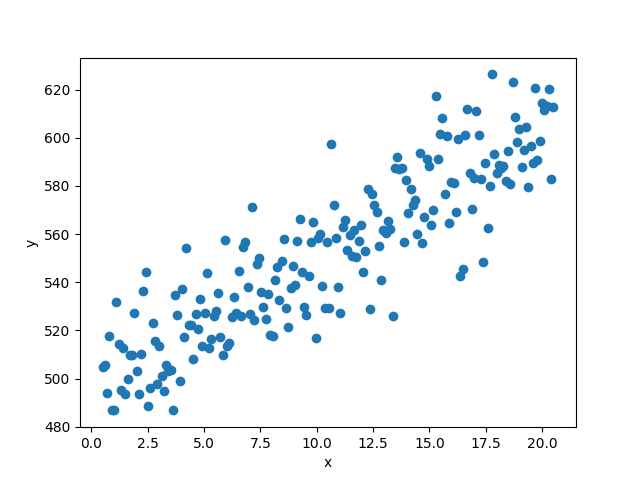

```python
xs = np.linspace(0.5, 20.5, 200)
ys = 5*(xs+3*np.random.randn(xs.shape[0])) + 500

fig, ax = plt.subplots()
ax.scatter(xs, ys)
ax.set_xlabel("x")
ax.set_ylabel("y")
```

We will do our prediction by finding the line that minimizes the Euclidean (straight line) distance between each point and the line.

\begin{align*} y_i &= mx_i + b \\ \min_{m, b} & \frac{1}{2} \sum_i \left( mx_i + b - y_i \right)^2 \end{align*}

However, we can re-write this as a matrix operation:

\begin{align*} y_i &= mx_i + b \\ y_i &= \begin{bmatrix} x_i & 1 \end{bmatrix} \begin{bmatrix} m \\ b \end{bmatrix} \\ \end{align*}

Therefore

\begin{align*} X &= \begin{bmatrix} x_0 & 1 \\ x_1 & 1 \\ \vdots & \vdots \\ x_{N-2} & 1 \\ x_{N-1} & 1 \end{bmatrix} \\ \theta &= \begin{bmatrix} m \\ b \end{bmatrix} \\ Y &= \begin{bmatrix} y_0 \\ y_1 \\ \vdots \\ y_{N-2} \\ y_{N-1} \end{bmatrix} \\ \min_{\theta} & \left( \frac{1}{2} \left|\left| X \theta - Y \right|\right|^2 = \frac{1}{2} \sum_i \left( \begin{bmatrix} x & 1 \end{bmatrix} \theta - y_i \right)^2 \right) \end{align*}

By now, you might be able to see that, while this is a two dimensional example, this is easily generalizable to $m$ dimensions, since this would just make $X$ an $n \times m$ matrix and $\theta$ a $m$-length vector.

To solve, we would take a derivative with respect to $\theta$ and set it to 0, but we can just use one of the many solvers available through python

```python
def linear_regression(xs, ys, fractest=0.2, plot=False, sk_intercept=True, man_intercept=False,
                      ret_test=True, ret_pred=True):
    xs = xs.reshape(xs.shape[0], -1)
    ys = ys.reshape(ys.shape[0], -1)
    if man_intercept and not sk_intercept:
        print("Changing the data by adding a row of 1s for all data points.")
        print("The function will fit the slope of the line and the intercept.")
        xs = np.hstack((xs, np.ones_like(xs)))
    elif man_intercept and sk_intercept:
        print("Using sklearn's intercept finding ability instead of changing the data to allow for intercepts.")
    # Split data into train and test data
    print("X shape:", xs.shape)
    print("Y shape:", ys.shape)
#     choices = np.random.randint(xs.shape[0], size=round(xs.shape[0]*(1-fractest)))
#     null_choices = np.array([i for i in np.arange(xs.shape[0]) if i not in choices])

#     xtrain = xs[choices,:]#.reshape(-1,1)
#     ytrain = ys[choices,:]#.reshape(-1,1)
#     xtest = xs[null_choices,:]#.reshape(-1,1)
#     ytest = ys[null_choices,:]#.reshape(-1,1)

    xtrain, xtest, ytrain, ytest = sklearn.model_selection.train_test_split(xs, ys, test_size=fractest)

    # Create linear regression object
    regr = linear_model.LinearRegression(fit_intercept=sk_intercept)

    # Train the model using the training sets
    regr.fit(xtrain, ytrain)

    # Make predictions using the testing set
    ypred = regr.predict(xtest)

    # The coefficients
    print('Coefficients: \n', regr.coef_)
    # The mean squared error
    print("Mean squared error: %.2f"
          % mean_squared_error(ytest, ypred))
    # Explained variance score: 1 is perfect prediction
    print('Variance score: %.2f' % r2_score(ytest, ypred))

    if plot:
        # Plot outputs
        plt.figure()
        print(xtest.shape, ytest.shape)
        plt.scatter(xtest[:,0], ytest,  color='red', label="Testing Data")
        plt.scatter(xtrain[:,0], ytrain, facecolors="none", edgecolors="black", label="Training Data")
        plt.plot(xtest[:,0], ypred, color='blue', linewidth=3, label="Prediction")
        plt.xlabel('x')
        plt.ylabel('y')
        plt.legend(loc='best')

        # plt.xticks(())
        # plt.yticks(())

        plt.show()

    if ret_test and ret_pred:
        return xtest, ytest, ypred, regr
    elif ret_test:
        return xtest, ytest, regr
    elif ret_pred:
        return ypred, regr
```

```
X shape: (200, 1)
Y shape: (200, 1)
Coefficients:
 [[ 5.30582511]]
Mean squared error: 284.41
Variance score: 0.72
```

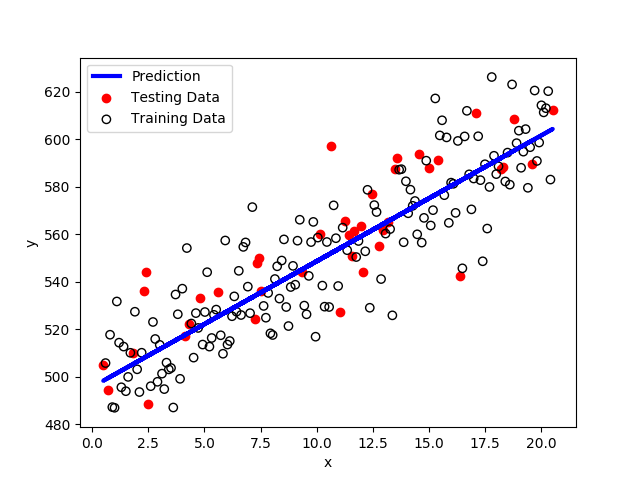

```
(40, 1) (40, 1)
```

```python
data = linear_regression(xs, ys, fractest=0.2, plot=True, sk_intercept=True, man_intercept=False,
                         ret_test=True, ret_pred=True)
```

Now we will do a multi-dimensional example with home prices. The dataset has information like how many rooms each house has, square footage, etc. and the final piece of information is the price (in $1000). We would like to make a model to find the price for arbitrary housing information based on this data.

```python
# M dimensional example
housing = pd.read_csv("~/machlearn_workshop/session01/stanford_dl_ex/ex1/housing.data", delim_whitespace=True, header=-1)
print("Housing shape:", housing.shape)
housing
```

```
Housing shape: (506, 14)
```

|  | 0 | 1 | 2 | 3 | 4 | 5 | 6 | 7 | 8 | 9 | 10 | 11 | 12 | 13 |
| --- | --- | --- | --- | --- | --- | --- | --- | --- | --- | --- | --- | --- | --- | --- |
| 0 | 0.00632 | 18.0 | 2.31 | 0 | 0.538 | 6.575 | 65.2 | 4.0900 | 1 | 296.0 | 15.3 | 396.90 | 4.98 | 24.0 |
| 1 | 0.02731 | 0.0 | 7.07 | 0 | 0.469 | 6.421 | 78.9 | 4.9671 | 2 | 242.0 | 17.8 | 396.90 | 9.14 | 21.6 |
| 2 | 0.02729 | 0.0 | 7.07 | 0 | 0.469 | 7.185 | 61.1 | 4.9671 | 2 | 242.0 | 17.8 | 392.83 | 4.03 | 34.7 |
| 3 | 0.03237 | 0.0 | 2.18 | 0 | 0.458 | 6.998 | 45.8 | 6.0622 | 3 | 222.0 | 18.7 | 394.63 | 2.94 | 33.4 |
| 4 | 0.06905 | 0.0 | 2.18 | 0 | 0.458 | 7.147 | 54.2 | 6.0622 | 3 | 222.0 | 18.7 | 396.90 | 5.33 | 36.2 |
| 5 | 0.02985 | 0.0 | 2.18 | 0 | 0.458 | 6.430 | 58.7 | 6.0622 | 3 | 222.0 | 18.7 | 394.12 | 5.21 | 28.7 |
| 6 | 0.08829 | 12.5 | 7.87 | 0 | 0.524 | 6.012 | 66.6 | 5.5605 | 5 | 311.0 | 15.2 | 395.60 | 12.43 | 22.9 |
| 7 | 0.14455 | 12.5 | 7.87 | 0 | 0.524 | 6.172 | 96.1 | 5.9505 | 5 | 311.0 | 15.2 | 396.90 | 19.15 | 27.1 |
| 8 | 0.21124 | 12.5 | 7.87 | 0 | 0.524 | 5.631 | 100.0 | 6.0821 | 5 | 311.0 | 15.2 | 386.63 | 29.93 | 16.5 |
| 9 | 0.17004 | 12.5 | 7.87 | 0 | 0.524 | 6.004 | 85.9 | 6.5921 | 5 | 311.0 | 15.2 | 386.71 | 17.10 | 18.9 |
| 10 | 0.22489 | 12.5 | 7.87 | 0 | 0.524 | 6.377 | 94.3 | 6.3467 | 5 | 311.0 | 15.2 | 392.52 | 20.45 | 15.0 |
| 11 | 0.11747 | 12.5 | 7.87 | 0 | 0.524 | 6.009 | 82.9 | 6.2267 | 5 | 311.0 | 15.2 | 396.90 | 13.27 | 18.9 |
| 12 | 0.09378 | 12.5 | 7.87 | 0 | 0.524 | 5.889 | 39.0 | 5.4509 | 5 | 311.0 | 15.2 | 390.50 | 15.71 | 21.7 |
| 13 | 0.62976 | 0.0 | 8.14 | 0 | 0.538 | 5.949 | 61.8 | 4.7075 | 4 | 307.0 | 21.0 | 396.90 | 8.26 | 20.4 |
| 14 | 0.63796 | 0.0 | 8.14 | 0 | 0.538 | 6.096 | 84.5 | 4.4619 | 4 | 307.0 | 21.0 | 380.02 | 10.26 | 18.2 |
| 15 | 0.62739 | 0.0 | 8.14 | 0 | 0.538 | 5.834 | 56.5 | 4.4986 | 4 | 307.0 | 21.0 | 395.62 | 8.47 | 19.9 |
| 16 | 1.05393 | 0.0 | 8.14 | 0 | 0.538 | 5.935 | 29.3 | 4.4986 | 4 | 307.0 | 21.0 | 386.85 | 6.58 | 23.1 |
| 17 | 0.78420 | 0.0 | 8.14 | 0 | 0.538 | 5.990 | 81.7 | 4.2579 | 4 | 307.0 | 21.0 | 386.75 | 14.67 | 17.5 |
| 18 | 0.80271 | 0.0 | 8.14 | 0 | 0.538 | 5.456 | 36.6 | 3.7965 | 4 | 307.0 | 21.0 | 288.99 | 11.69 | 20.2 |
| 19 | 0.72580 | 0.0 | 8.14 | 0 | 0.538 | 5.727 | 69.5 | 3.7965 | 4 | 307.0 | 21.0 | 390.95 | 11.28 | 18.2 |
| 20 | 1.25179 | 0.0 | 8.14 | 0 | 0.538 | 5.570 | 98.1 | 3.7979 | 4 | 307.0 | 21.0 | 376.57 | 21.02 | 13.6 |
| 21 | 0.85204 | 0.0 | 8.14 | 0 | 0.538 | 5.965 | 89.2 | 4.0123 | 4 | 307.0 | 21.0 | 392.53 | 13.83 | 19.6 |
| 22 | 1.23247 | 0.0 | 8.14 | 0 | 0.538 | 6.142 | 91.7 | 3.9769 | 4 | 307.0 | 21.0 | 396.90 | 18.72 | 15.2 |
| 23 | 0.98843 | 0.0 | 8.14 | 0 | 0.538 | 5.813 | 100.0 | 4.0952 | 4 | 307.0 | 21.0 | 394.54 | 19.88 | 14.5 |
| 24 | 0.75026 | 0.0 | 8.14 | 0 | 0.538 | 5.924 | 94.1 | 4.3996 | 4 | 307.0 | 21.0 | 394.33 | 16.30 | 15.6 |
| 25 | 0.84054 | 0.0 | 8.14 | 0 | 0.538 | 5.599 | 85.7 | 4.4546 | 4 | 307.0 | 21.0 | 303.42 | 16.51 | 13.9 |
| 26 | 0.67191 | 0.0 | 8.14 | 0 | 0.538 | 5.813 | 90.3 | 4.6820 | 4 | 307.0 | 21.0 | 376.88 | 14.81 | 16.6 |
| 27 | 0.95577 | 0.0 | 8.14 | 0 | 0.538 | 6.047 | 88.8 | 4.4534 | 4 | 307.0 | 21.0 | 306.38 | 17.28 | 14.8 |
| 28 | 0.77299 | 0.0 | 8.14 | 0 | 0.538 | 6.495 | 94.4 | 4.4547 | 4 | 307.0 | 21.0 | 387.94 | 12.80 | 18.4 |
| 29 | 1.00245 | 0.0 | 8.14 | 0 | 0.538 | 6.674 | 87.3 | 4.2390 | 4 | 307.0 | 21.0 | 380.23 | 11.98 | 21.0 |
| ... | ... | ... | ... | ... | ... | ... | ... | ... | ... | ... | ... | ... | ... | ... |
| 476 | 4.87141 | 0.0 | 18.10 | 0 | 0.614 | 6.484 | 93.6 | 2.3053 | 24 | 666.0 | 20.2 | 396.21 | 18.68 | 16.7 |
| 477 | 15.02340 | 0.0 | 18.10 | 0 | 0.614 | 5.304 | 97.3 | 2.1007 | 24 | 666.0 | 20.2 | 349.48 | 24.91 | 12.0 |
| 478 | 10.23300 | 0.0 | 18.10 | 0 | 0.614 | 6.185 | 96.7 | 2.1705 | 24 | 666.0 | 20.2 | 379.70 | 18.03 | 14.6 |
| 479 | 14.33370 | 0.0 | 18.10 | 0 | 0.614 | 6.229 | 88.0 | 1.9512 | 24 | 666.0 | 20.2 | 383.32 | 13.11 | 21.4 |
| 480 | 5.82401 | 0.0 | 18.10 | 0 | 0.532 | 6.242 | 64.7 | 3.4242 | 24 | 666.0 | 20.2 | 396.90 | 10.74 | 23.0 |
| 481 | 5.70818 | 0.0 | 18.10 | 0 | 0.532 | 6.750 | 74.9 | 3.3317 | 24 | 666.0 | 20.2 | 393.07 | 7.74 | 23.7 |
| 482 | 5.73116 | 0.0 | 18.10 | 0 | 0.532 | 7.061 | 77.0 | 3.4106 | 24 | 666.0 | 20.2 | 395.28 | 7.01 | 25.0 |
| 483 | 2.81838 | 0.0 | 18.10 | 0 | 0.532 | 5.762 | 40.3 | 4.0983 | 24 | 666.0 | 20.2 | 392.92 | 10.42 | 21.8 |
| 484 | 2.37857 | 0.0 | 18.10 | 0 | 0.583 | 5.871 | 41.9 | 3.7240 | 24 | 666.0 | 20.2 | 370.73 | 13.34 | 20.6 |
| 485 | 3.67367 | 0.0 | 18.10 | 0 | 0.583 | 6.312 | 51.9 | 3.9917 | 24 | 666.0 | 20.2 | 388.62 | 10.58 | 21.2 |
| 486 | 5.69175 | 0.0 | 18.10 | 0 | 0.583 | 6.114 | 79.8 | 3.5459 | 24 | 666.0 | 20.2 | 392.68 | 14.98 | 19.1 |
| 487 | 4.83567 | 0.0 | 18.10 | 0 | 0.583 | 5.905 | 53.2 | 3.1523 | 24 | 666.0 | 20.2 | 388.22 | 11.45 | 20.6 |
| 488 | 0.15086 | 0.0 | 27.74 | 0 | 0.609 | 5.454 | 92.7 | 1.8209 | 4 | 711.0 | 20.1 | 395.09 | 18.06 | 15.2 |
| 489 | 0.18337 | 0.0 | 27.74 | 0 | 0.609 | 5.414 | 98.3 | 1.7554 | 4 | 711.0 | 20.1 | 344.05 | 23.97 | 7.0 |
| 490 | 0.20746 | 0.0 | 27.74 | 0 | 0.609 | 5.093 | 98.0 | 1.8226 | 4 | 711.0 | 20.1 | 318.43 | 29.68 | 8.1 |
| 491 | 0.10574 | 0.0 | 27.74 | 0 | 0.609 | 5.983 | 98.8 | 1.8681 | 4 | 711.0 | 20.1 | 390.11 | 18.07 | 13.6 |
| 492 | 0.11132 | 0.0 | 27.74 | 0 | 0.609 | 5.983 | 83.5 | 2.1099 | 4 | 711.0 | 20.1 | 396.90 | 13.35 | 20.1 |
| 493 | 0.17331 | 0.0 | 9.69 | 0 | 0.585 | 5.707 | 54.0 | 2.3817 | 6 | 391.0 | 19.2 | 396.90 | 12.01 | 21.8 |
| 494 | 0.27957 | 0.0 | 9.69 | 0 | 0.585 | 5.926 | 42.6 | 2.3817 | 6 | 391.0 | 19.2 | 396.90 | 13.59 | 24.5 |
| 495 | 0.17899 | 0.0 | 9.69 | 0 | 0.585 | 5.670 | 28.8 | 2.7986 | 6 | 391.0 | 19.2 | 393.29 | 17.60 | 23.1 |
| 496 | 0.28960 | 0.0 | 9.69 | 0 | 0.585 | 5.390 | 72.9 | 2.7986 | 6 | 391.0 | 19.2 | 396.90 | 21.14 | 19.7 |
| 497 | 0.26838 | 0.0 | 9.69 | 0 | 0.585 | 5.794 | 70.6 | 2.8927 | 6 | 391.0 | 19.2 | 396.90 | 14.10 | 18.3 |
| 498 | 0.23912 | 0.0 | 9.69 | 0 | 0.585 | 6.019 | 65.3 | 2.4091 | 6 | 391.0 | 19.2 | 396.90 | 12.92 | 21.2 |
| 499 | 0.17783 | 0.0 | 9.69 | 0 | 0.585 | 5.569 | 73.5 | 2.3999 | 6 | 391.0 | 19.2 | 395.77 | 15.10 | 17.5 |
| 500 | 0.22438 | 0.0 | 9.69 | 0 | 0.585 | 6.027 | 79.7 | 2.4982 | 6 | 391.0 | 19.2 | 396.90 | 14.33 | 16.8 |
| 501 | 0.06263 | 0.0 | 11.93 | 0 | 0.573 | 6.593 | 69.1 | 2.4786 | 1 | 273.0 | 21.0 | 391.99 | 9.67 | 22.4 |
| 502 | 0.04527 | 0.0 | 11.93 | 0 | 0.573 | 6.120 | 76.7 | 2.2875 | 1 | 273.0 | 21.0 | 396.90 | 9.08 | 20.6 |
| 503 | 0.06076 | 0.0 | 11.93 | 0 | 0.573 | 6.976 | 91.0 | 2.1675 | 1 | 273.0 | 21.0 | 396.90 | 5.64 | 23.9 |
| 504 | 0.10959 | 0.0 | 11.93 | 0 | 0.573 | 6.794 | 89.3 | 2.3889 | 1 | 273.0 | 21.0 | 393.45 | 6.48 | 22.0 |
| 505 | 0.04741 | 0.0 | 11.93 | 0 | 0.573 | 6.030 | 80.8 | 2.5050 | 1 | 273.0 | 21.0 | 396.90 | 7.88 | 11.9 |

506 rows × 14 columns

```python
housing.shape
xhous = housing.iloc[:,:-1]
xhous = np.array(xhous)
print("X shape:", xhous.shape)
yhous = housing.iloc[:,-1]
yhous = np.array(yhous)
print("Y shape:", yhous.shape)
```

```
X shape: (506, 13)
Y shape: (506,)
```

```python
data = linear_regression(xhous, yhous, fractest=0.2, plot=False, sk_intercept=True, man_intercept=False,
                         ret_test=True, ret_pred=True)
```

```
X shape: (506, 13)
Y shape: (506, 1)
Coefficients:
 [[ -1.31510285e-01   4.13974209e-02   6.25160985e-03   2.79016446e+00
   -1.89766171e+01   3.30619686e+00   5.22476194e-03  -1.43095740e+00
    3.15034111e-01  -1.03929737e-02  -1.01011989e+00   9.86838573e-03
   -5.34735244e-01]]
Mean squared error: 18.95
Variance score: 0.80
```

```
(102, 13)
(102, 1)
(102, 1)
```

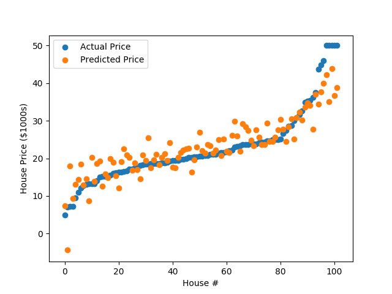

```python
print(data[0].shape)
print(data[1].shape)
print(data[2].shape)
sorted_inds = np.argsort(data[1], axis=0)
plt.figure()
plt.scatter(np.arange(data[0].shape[0]), data[1][sorted_inds], label="Actual Price")
plt.scatter(np.arange(data[0].shape[0]), data[2][sorted_inds], label="Predicted Price")
plt.legend(loc='best')
plt.xlabel('House #')
plt.ylabel('House Price ($1000s)')
plt.plot()
plt.show()
```

## Linear Regression Pros and Cons

Pros:

- Quick to implement and run
- Easy to understand
- Good for predicting continuous values

Cons:

- Must fit data to a line
- Must know true values for training (supervised)
- Bad for predicting labels not tied to a continuous value

[figure not shown]

## Logistic Regression

Suppose that instead of predicting a continuum of values, we just wanted to classify our dataset into 2 categories. Doing so with a linear regression could be done if the categories were well separated on some continuum (i.e. if $x_i\theta < k$ then 0; else 1), but this requires tuning k and does not work if the labels are not well separated on a continuum. For this, we look toward Logistic Regression.

What we are minimizing:

\begin{align*} J(\theta) &= -\sum_i(y_i \log(h_\theta(x_i)) + (1 - y_i) \log(1 - h_\theta(x_i))) \\ &= -\sum_i( \mathbf{1}(y_i=1) \cdot \log(h_\theta(x_i)) + \mathbf{1}(y_i=0) \cdot \log(1 - h_\theta(x_i))) \\ \end{align*}

Where the $\mathbf{1}(\text{condition})$ is the indicator function ($1$ if condition is True, $0$ if condition is False).

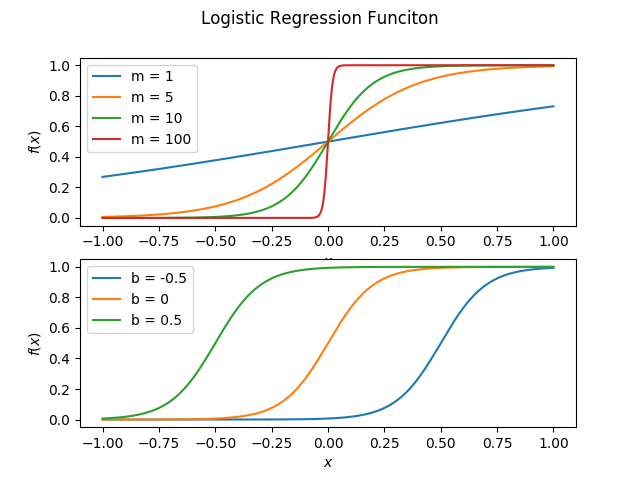

```python
xs = np.linspace(-1, 1, 1000)
ms = [1, 5, 10, 100]
bs = [-0.5, 0, 0.5]

fig, ax = plt.subplots(2)

for m in ms:
    fxs = 1/(1+np.exp(-m*xs))
    ax[0].plot(xs, fxs, label="m = {}".format(m))

for b in bs:
    fxs = 1/(1+np.exp(-10*(xs+b)))
    ax[1].plot(xs, fxs, label="b = {}".format(b))

plt.suptitle("Logistic Regression Funciton")

for i in range(2):
    ax[i].set_xlabel('$x$')
    ax[i].set_ylabel('$f(x)$')
    ax[i].legend(loc='best')


plt.show()
```

### Example: Spam Filtering

We want to filter spam vs. not spam by looking at a set of labeled examples saying spam and not spam. The dataset is shown below. The features are things like the frequency of key words or characters such as "password", "\$", "address", etc. and longest capital run length, etc. The last label is $1$ for spam or $0$ for not spam. We will use this to train our filter. All data available from ftp://ftp.ics.uci.edu/pub/machine-learning-databases/spambase

```python
def logistic_regression(xs, ys, fractest=0.2, ret_test=True, ret_pred=True):
    xs = xs.reshape(xs.shape[0], -1)
#     ys = ys.reshape(ys.shape[0], -1)
    print("X shape:", xs.shape)
    print("Y shape:", ys.shape)
    xtrain, xtest, ytrain, ytest = sklearn.model_selection.train_test_split(xs, ys, test_size=fractest)

    # Create logistic regression object
    logreg = linear_model.LogisticRegression()

    # Fit train data
    logreg.fit(xtrain, ytrain)

    # Make predictions
    ypred = logreg.predict(xtest)

    # The coefficients
    print('Coefficients: \n', logreg.coef_)
    # The mean squared error
    print("Mean squared error: %.2f"
          % mean_squared_error(ytest, ypred))
    # Explained variance score: 1 is perfect prediction
    print('Variance score: %.2f' % r2_score(ytest, ypred))
```

```python
emails = pd.read_csv("spambase/spambase.data", header=-1)
emails
```

|  | 0 | 1 | 2 | 3 | 4 | 5 | 6 | 7 | 8 | 9 | ... | 48 | 49 | 50 | 51 | 52 | 53 | 54 | 55 | 56 | 57 |
| --- | --- | --- | --- | --- | --- | --- | --- | --- | --- | --- | --- | --- | --- | --- | --- | --- | --- | --- | --- | --- | --- |
| 0 | 0.00 | 0.64 | 0.64 | 0.0 | 0.32 | 0.00 | 0.00 | 0.00 | 0.00 | 0.00 | ... | 0.000 | 0.000 | 0.000 | 0.778 | 0.000 | 0.000 | 3.756 | 61 | 278 | 1 |
| 1 | 0.21 | 0.28 | 0.50 | 0.0 | 0.14 | 0.28 | 0.21 | 0.07 | 0.00 | 0.94 | ... | 0.000 | 0.132 | 0.000 | 0.372 | 0.180 | 0.048 | 5.114 | 101 | 1028 | 1 |
| 2 | 0.06 | 0.00 | 0.71 | 0.0 | 1.23 | 0.19 | 0.19 | 0.12 | 0.64 | 0.25 | ... | 0.010 | 0.143 | 0.000 | 0.276 | 0.184 | 0.010 | 9.821 | 485 | 2259 | 1 |
| 3 | 0.00 | 0.00 | 0.00 | 0.0 | 0.63 | 0.00 | 0.31 | 0.63 | 0.31 | 0.63 | ... | 0.000 | 0.137 | 0.000 | 0.137 | 0.000 | 0.000 | 3.537 | 40 | 191 | 1 |
| 4 | 0.00 | 0.00 | 0.00 | 0.0 | 0.63 | 0.00 | 0.31 | 0.63 | 0.31 | 0.63 | ... | 0.000 | 0.135 | 0.000 | 0.135 | 0.000 | 0.000 | 3.537 | 40 | 191 | 1 |
| 5 | 0.00 | 0.00 | 0.00 | 0.0 | 1.85 | 0.00 | 0.00 | 1.85 | 0.00 | 0.00 | ... | 0.000 | 0.223 | 0.000 | 0.000 | 0.000 | 0.000 | 3.000 | 15 | 54 | 1 |
| 6 | 0.00 | 0.00 | 0.00 | 0.0 | 1.92 | 0.00 | 0.00 | 0.00 | 0.00 | 0.64 | ... | 0.000 | 0.054 | 0.000 | 0.164 | 0.054 | 0.000 | 1.671 | 4 | 112 | 1 |
| 7 | 0.00 | 0.00 | 0.00 | 0.0 | 1.88 | 0.00 | 0.00 | 1.88 | 0.00 | 0.00 | ... | 0.000 | 0.206 | 0.000 | 0.000 | 0.000 | 0.000 | 2.450 | 11 | 49 | 1 |
| 8 | 0.15 | 0.00 | 0.46 | 0.0 | 0.61 | 0.00 | 0.30 | 0.00 | 0.92 | 0.76 | ... | 0.000 | 0.271 | 0.000 | 0.181 | 0.203 | 0.022 | 9.744 | 445 | 1257 | 1 |
| 9 | 0.06 | 0.12 | 0.77 | 0.0 | 0.19 | 0.32 | 0.38 | 0.00 | 0.06 | 0.00 | ... | 0.040 | 0.030 | 0.000 | 0.244 | 0.081 | 0.000 | 1.729 | 43 | 749 | 1 |
| 10 | 0.00 | 0.00 | 0.00 | 0.0 | 0.00 | 0.00 | 0.96 | 0.00 | 0.00 | 1.92 | ... | 0.000 | 0.000 | 0.000 | 0.462 | 0.000 | 0.000 | 1.312 | 6 | 21 | 1 |
| 11 | 0.00 | 0.00 | 0.25 | 0.0 | 0.38 | 0.25 | 0.25 | 0.00 | 0.00 | 0.00 | ... | 0.022 | 0.044 | 0.000 | 0.663 | 0.000 | 0.000 | 1.243 | 11 | 184 | 1 |
| 12 | 0.00 | 0.69 | 0.34 | 0.0 | 0.34 | 0.00 | 0.00 | 0.00 | 0.00 | 0.00 | ... | 0.000 | 0.056 | 0.000 | 0.786 | 0.000 | 0.000 | 3.728 | 61 | 261 | 1 |
| 13 | 0.00 | 0.00 | 0.00 | 0.0 | 0.90 | 0.00 | 0.90 | 0.00 | 0.00 | 0.90 | ... | 0.000 | 0.000 | 0.000 | 0.000 | 0.000 | 0.000 | 2.083 | 7 | 25 | 1 |
| 14 | 0.00 | 0.00 | 1.42 | 0.0 | 0.71 | 0.35 | 0.00 | 0.35 | 0.00 | 0.71 | ... | 0.000 | 0.102 | 0.000 | 0.357 | 0.000 | 0.000 | 1.971 | 24 | 205 | 1 |
| 15 | 0.00 | 0.42 | 0.42 | 0.0 | 1.27 | 0.00 | 0.42 | 0.00 | 0.00 | 1.27 | ... | 0.000 | 0.063 | 0.000 | 0.572 | 0.063 | 0.000 | 5.659 | 55 | 249 | 1 |
| 16 | 0.00 | 0.00 | 0.00 | 0.0 | 0.94 | 0.00 | 0.00 | 0.00 | 0.00 | 0.00 | ... | 0.000 | 0.000 | 0.000 | 0.428 | 0.000 | 0.000 | 4.652 | 31 | 107 | 1 |
| 17 | 0.00 | 0.00 | 0.00 | 0.0 | 0.00 | 0.00 | 0.00 | 0.00 | 0.00 | 0.00 | ... | 0.000 | 0.000 | 0.000 | 1.975 | 0.370 | 0.000 | 35.461 | 95 | 461 | 1 |
| 18 | 0.00 | 0.00 | 0.55 | 0.0 | 1.11 | 0.00 | 0.18 | 0.00 | 0.00 | 0.00 | ... | 0.000 | 0.182 | 0.000 | 0.455 | 0.000 | 0.000 | 1.320 | 4 | 70 | 1 |
| 19 | 0.00 | 0.63 | 0.00 | 0.0 | 1.59 | 0.31 | 0.00 | 0.00 | 0.31 | 0.00 | ... | 0.000 | 0.275 | 0.000 | 0.055 | 0.496 | 0.000 | 3.509 | 91 | 186 | 1 |
| 20 | 0.00 | 0.00 | 0.00 | 0.0 | 0.00 | 0.00 | 0.00 | 0.00 | 0.00 | 0.00 | ... | 0.000 | 0.729 | 0.000 | 0.729 | 0.000 | 0.000 | 3.833 | 9 | 23 | 1 |
| 21 | 0.05 | 0.07 | 0.10 | 0.0 | 0.76 | 0.05 | 0.15 | 0.02 | 0.55 | 0.00 | ... | 0.042 | 0.101 | 0.016 | 0.250 | 0.046 | 0.059 | 2.569 | 66 | 2259 | 1 |
| 22 | 0.00 | 0.00 | 0.00 | 0.0 | 2.94 | 0.00 | 0.00 | 0.00 | 0.00 | 0.00 | ... | 0.404 | 0.404 | 0.000 | 0.809 | 0.000 | 0.000 | 4.857 | 12 | 34 | 1 |
| 23 | 0.00 | 0.00 | 0.00 | 0.0 | 1.16 | 0.00 | 0.00 | 0.00 | 0.00 | 0.00 | ... | 0.000 | 0.133 | 0.000 | 0.667 | 0.000 | 0.000 | 1.131 | 5 | 69 | 1 |
| 24 | 0.00 | 0.00 | 0.00 | 0.0 | 0.00 | 0.00 | 0.00 | 0.00 | 0.00 | 0.00 | ... | 0.000 | 0.196 | 0.000 | 0.392 | 0.196 | 0.000 | 5.466 | 22 | 82 | 1 |
| 25 | 0.05 | 0.07 | 0.10 | 0.0 | 0.76 | 0.05 | 0.15 | 0.02 | 0.55 | 0.00 | ... | 0.042 | 0.101 | 0.016 | 0.250 | 0.046 | 0.059 | 2.565 | 66 | 2258 | 1 |
| 26 | 0.00 | 0.00 | 0.00 | 0.0 | 0.00 | 0.00 | 0.00 | 0.00 | 0.00 | 0.00 | ... | 0.000 | 0.196 | 0.000 | 0.392 | 0.196 | 0.000 | 5.466 | 22 | 82 | 1 |
| 27 | 0.00 | 0.00 | 0.00 | 0.0 | 0.00 | 0.00 | 1.66 | 0.00 | 0.00 | 0.00 | ... | 0.000 | 0.000 | 0.000 | 0.368 | 0.000 | 0.000 | 2.611 | 12 | 47 | 1 |
| 28 | 0.00 | 0.00 | 0.00 | 0.0 | 0.00 | 0.00 | 0.00 | 0.00 | 0.00 | 0.00 | ... | 0.000 | 0.352 | 0.000 | 0.352 | 0.000 | 0.000 | 4.000 | 11 | 36 | 1 |
| 29 | 0.00 | 0.00 | 0.00 | 0.0 | 0.65 | 0.00 | 0.65 | 0.00 | 0.00 | 0.00 | ... | 0.000 | 0.459 | 0.000 | 0.091 | 0.000 | 0.000 | 2.687 | 66 | 129 | 1 |
| ... | ... | ... | ... | ... | ... | ... | ... | ... | ... | ... | ... | ... | ... | ... | ... | ... | ... | ... | ... | ... | ... |
| 4571 | 0.00 | 0.00 | 0.46 | 0.0 | 0.23 | 0.23 | 0.00 | 0.00 | 0.00 | 0.00 | ... | 0.000 | 0.082 | 0.000 | 0.082 | 0.000 | 0.000 | 1.256 | 5 | 98 | 0 |
| 4572 | 0.00 | 0.00 | 0.00 | 0.0 | 0.00 | 0.00 | 0.00 | 0.00 | 0.00 | 0.00 | ... | 0.000 | 0.254 | 0.000 | 0.000 | 0.000 | 0.000 | 1.000 | 1 | 13 | 0 |
| 4573 | 0.00 | 0.00 | 0.18 | 0.0 | 0.18 | 0.18 | 0.00 | 0.00 | 0.00 | 0.00 | ... | 0.033 | 0.033 | 0.000 | 0.099 | 0.000 | 0.000 | 1.489 | 11 | 137 | 0 |
| 4574 | 0.29 | 0.00 | 0.29 | 0.0 | 0.00 | 0.00 | 0.00 | 0.00 | 0.00 | 0.29 | ... | 0.000 | 0.107 | 0.000 | 0.000 | 0.000 | 0.000 | 1.220 | 6 | 61 | 0 |
| 4575 | 0.00 | 0.00 | 0.00 | 0.0 | 0.00 | 0.00 | 0.00 | 0.00 | 0.00 | 1.38 | ... | 0.000 | 0.213 | 0.000 | 0.000 | 0.000 | 0.000 | 1.720 | 11 | 43 | 0 |
| 4576 | 0.00 | 0.00 | 0.00 | 0.0 | 0.00 | 0.00 | 0.00 | 0.00 | 0.00 | 0.00 | ... | 0.000 | 0.131 | 0.000 | 0.000 | 0.000 | 0.000 | 1.488 | 5 | 64 | 0 |
| 4577 | 0.00 | 0.00 | 1.20 | 0.0 | 0.00 | 0.00 | 0.00 | 0.00 | 0.00 | 0.00 | ... | 0.000 | 0.000 | 0.000 | 0.000 | 0.000 | 0.000 | 1.200 | 3 | 24 | 0 |
| 4578 | 0.00 | 0.00 | 0.40 | 0.0 | 0.00 | 0.00 | 0.00 | 0.00 | 0.00 | 0.00 | ... | 0.000 | 0.000 | 0.145 | 0.000 | 0.000 | 0.000 | 1.372 | 5 | 70 | 0 |
| 4579 | 0.27 | 0.05 | 0.10 | 0.0 | 0.00 | 0.00 | 0.00 | 0.00 | 0.00 | 0.00 | ... | 0.607 | 0.064 | 0.036 | 0.055 | 0.000 | 0.202 | 3.766 | 43 | 1789 | 0 |
| 4580 | 0.00 | 0.00 | 0.00 | 0.0 | 0.00 | 0.00 | 0.00 | 0.00 | 0.00 | 0.00 | ... | 0.000 | 0.000 | 0.000 | 0.000 | 0.000 | 0.000 | 1.571 | 5 | 11 | 0 |
| 4581 | 0.00 | 0.00 | 0.00 | 0.0 | 0.00 | 0.51 | 0.00 | 0.00 | 0.00 | 0.00 | ... | 0.000 | 0.091 | 0.000 | 0.091 | 0.000 | 0.000 | 1.586 | 4 | 46 | 0 |
| 4582 | 0.00 | 0.00 | 0.00 | 0.0 | 0.00 | 0.00 | 0.00 | 0.00 | 0.00 | 0.00 | ... | 0.000 | 0.000 | 0.000 | 0.000 | 0.000 | 0.000 | 1.266 | 3 | 19 | 0 |
| 4583 | 0.00 | 0.00 | 1.23 | 0.0 | 0.00 | 0.00 | 0.00 | 0.00 | 0.00 | 0.00 | ... | 0.000 | 0.000 | 0.406 | 0.000 | 0.000 | 0.000 | 1.666 | 13 | 70 | 0 |
| 4584 | 0.00 | 0.00 | 0.45 | 0.0 | 0.00 | 0.22 | 0.00 | 0.00 | 0.00 | 0.00 | ... | 0.000 | 0.082 | 0.000 | 0.041 | 0.000 | 0.000 | 1.500 | 7 | 123 | 0 |
| 4585 | 0.00 | 0.00 | 0.00 | 0.0 | 0.00 | 0.00 | 0.00 | 0.00 | 0.00 | 0.00 | ... | 0.000 | 0.625 | 0.000 | 0.000 | 0.000 | 0.000 | 1.375 | 4 | 11 | 0 |
| 4586 | 0.00 | 0.00 | 0.00 | 0.0 | 0.36 | 0.00 | 0.00 | 0.00 | 0.00 | 0.00 | ... | 0.000 | 0.112 | 0.000 | 0.000 | 0.000 | 0.056 | 1.793 | 21 | 174 | 0 |
| 4587 | 0.00 | 0.00 | 0.00 | 0.0 | 0.00 | 0.00 | 0.00 | 0.00 | 0.00 | 0.00 | ... | 0.000 | 0.125 | 0.000 | 0.000 | 0.125 | 0.000 | 1.272 | 4 | 28 | 0 |
| 4588 | 0.00 | 0.00 | 3.03 | 0.0 | 0.00 | 0.00 | 0.00 | 0.00 | 0.00 | 0.00 | ... | 0.000 | 0.000 | 0.000 | 0.000 | 0.000 | 0.000 | 1.111 | 2 | 10 | 0 |
| 4589 | 0.00 | 0.00 | 0.00 | 0.0 | 0.54 | 0.00 | 0.00 | 0.00 | 0.00 | 0.00 | ... | 0.000 | 0.000 | 0.000 | 0.000 | 0.000 | 0.000 | 1.000 | 1 | 22 | 0 |
| 4590 | 0.00 | 0.00 | 0.00 | 0.0 | 0.00 | 0.00 | 0.00 | 0.00 | 0.00 | 0.00 | ... | 0.000 | 0.185 | 0.000 | 0.000 | 0.000 | 0.092 | 2.468 | 11 | 79 | 0 |
| 4591 | 0.00 | 0.00 | 0.00 | 0.0 | 0.00 | 0.00 | 0.00 | 0.00 | 0.00 | 0.00 | ... | 0.000 | 0.000 | 0.000 | 0.000 | 0.000 | 0.000 | 1.000 | 1 | 8 | 0 |
| 4592 | 0.00 | 0.00 | 1.25 | 0.0 | 2.50 | 0.00 | 0.00 | 0.00 | 0.00 | 0.00 | ... | 0.000 | 0.111 | 0.000 | 0.000 | 0.000 | 0.000 | 1.285 | 4 | 27 | 0 |
| 4593 | 0.00 | 0.00 | 0.00 | 0.0 | 0.00 | 0.00 | 0.00 | 0.00 | 0.00 | 0.00 | ... | 0.000 | 0.000 | 0.000 | 1.052 | 0.000 | 0.000 | 1.000 | 1 | 6 | 0 |
| 4594 | 0.00 | 0.00 | 0.00 | 0.0 | 0.00 | 0.00 | 0.00 | 0.00 | 0.00 | 0.00 | ... | 0.000 | 0.630 | 0.000 | 0.000 | 0.000 | 0.000 | 1.727 | 5 | 19 | 0 |
| 4595 | 0.00 | 0.00 | 1.19 | 0.0 | 0.00 | 0.00 | 0.00 | 0.00 | 0.00 | 0.00 | ... | 0.000 | 0.000 | 0.000 | 0.000 | 0.000 | 0.000 | 1.000 | 1 | 24 | 0 |
| 4596 | 0.31 | 0.00 | 0.62 | 0.0 | 0.00 | 0.31 | 0.00 | 0.00 | 0.00 | 0.00 | ... | 0.000 | 0.232 | 0.000 | 0.000 | 0.000 | 0.000 | 1.142 | 3 | 88 | 0 |
| 4597 | 0.00 | 0.00 | 0.00 | 0.0 | 0.00 | 0.00 | 0.00 | 0.00 | 0.00 | 0.00 | ... | 0.000 | 0.000 | 0.000 | 0.353 | 0.000 | 0.000 | 1.555 | 4 | 14 | 0 |
| 4598 | 0.30 | 0.00 | 0.30 | 0.0 | 0.00 | 0.00 | 0.00 | 0.00 | 0.00 | 0.00 | ... | 0.102 | 0.718 | 0.000 | 0.000 | 0.000 | 0.000 | 1.404 | 6 | 118 | 0 |
| 4599 | 0.96 | 0.00 | 0.00 | 0.0 | 0.32 | 0.00 | 0.00 | 0.00 | 0.00 | 0.00 | ... | 0.000 | 0.057 | 0.000 | 0.000 | 0.000 | 0.000 | 1.147 | 5 | 78 | 0 |
| 4600 | 0.00 | 0.00 | 0.65 | 0.0 | 0.00 | 0.00 | 0.00 | 0.00 | 0.00 | 0.00 | ... | 0.000 | 0.000 | 0.000 | 0.125 | 0.000 | 0.000 | 1.250 | 5 | 40 | 0 |

4601 rows × 58 columns

```python
emails.shape
xmail = emails.iloc[:,:-1]
xmail = np.array(xmail)
print("X shape:", xmail.shape)
ymail = emails.iloc[:,-1]
ymail = np.array(ymail)
print("Y shape:", ymail.shape)
```

```
X shape: (4601, 57)
Y shape: (4601,)
```

```python
data = logistic_regression(xmail, ymail, fractest=0.2)
```

```
X shape: (4601, 57)
Y shape: (4601,)
Coefficients:
 [[ -2.09159153e-01  -1.76610892e-01   1.50388638e-01   7.46000359e-01
    4.99948180e-01   1.18293076e+00   2.20171570e+00   5.41016773e-01
    6.61326900e-01   1.23344440e-01  -1.68900674e-02  -1.77076861e-01
    3.33207627e-02   1.07630029e-01   7.19623132e-01   9.55765639e-01
    7.55373552e-01   2.25624162e-01   5.82067135e-02   8.34410728e-01
    2.52999199e-01   2.33015356e-01   2.08724931e+00   4.55083145e-01
   -1.64990139e+00  -1.10794520e+00  -3.42910397e+00   4.05041402e-01
   -1.25328400e+00  -4.07531185e-01  -1.62433425e-01   2.37277117e-02
   -7.75239670e-01  -8.82028659e-02  -1.05718901e+00   8.98312349e-01
   -8.32020116e-02  -4.68485674e-01  -7.79652937e-01  -3.91322554e-01
   -1.62181186e+00  -1.69431090e+00  -5.27658307e-01  -1.34528479e+00
   -5.79712491e-01  -1.58492656e+00  -5.06024397e-01  -1.60926729e+00
   -1.06706264e+00  -2.03163973e-01  -4.53501654e-01   6.01396968e-01
    3.53489299e+00   1.16446597e+00  -1.16711732e-02   6.77039646e-03
    6.61466496e-04]]
Mean squared error: 0.07
Variance score: 0.70
```